# Laboratory Lab03 – Batch jobs with SLURM

**Author: Bartłomiej Jamiołkowski**

In this Jupyter Notebook, I am presenting the solutions to the Assignment.

## Assignment

### Assignment 1

Logging into Ares.

[figure not shown]

Downloading example animation Repeat Zone – Flower from blender website: https://mirrors.dotsrc.org/blender/demo/geometry-nodes/repeat_zone_flower_by_MiRA.blend  
There are more animations available under this link: https://www.blender.org/download/demo-files/  
Copying the file e.g to the access server ares.cyfronet.pl by using command from https://guide.plgrid.pl/en/computing/data_transfer/

[figure not shown]

Checking if the file was successfully copied to the access server ares.cyfronet.pl. The path of this file is also needed in order to move it to the -SCRATCH directory, which has more free space than the HOME directory.

Moving blender animation file to new directory SRATCH and checking if it was done successfully.

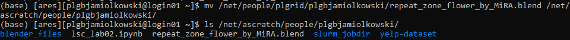

Moving to SCRATCH directory.

Creating or editing new job script called 'render_blender.sh'.

Including all parameters in the job script and loading blender from module.job script

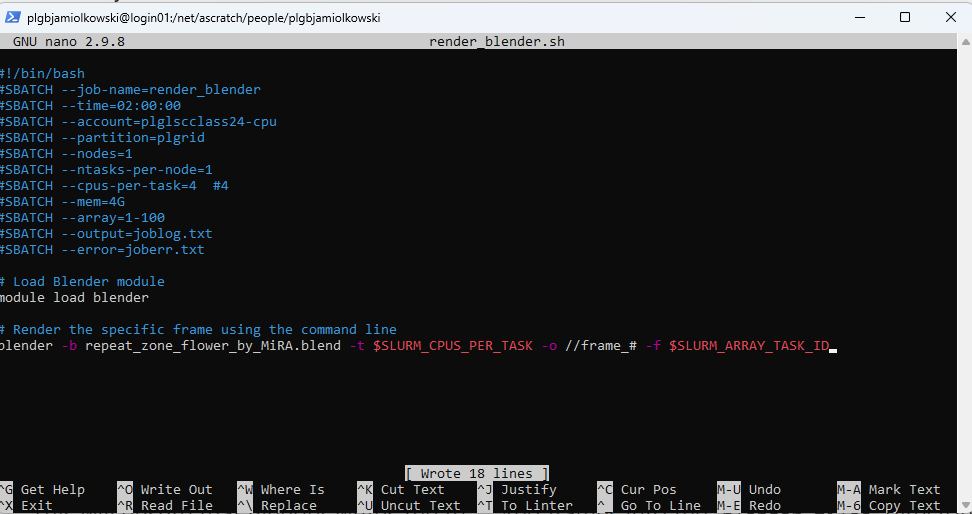

Running array job on cluster.

Viewing the status of jobs in the queue on a cluster.

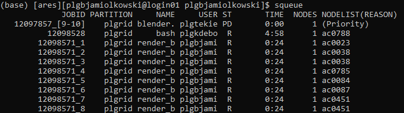

Checking if animation frames were rendered successfully.

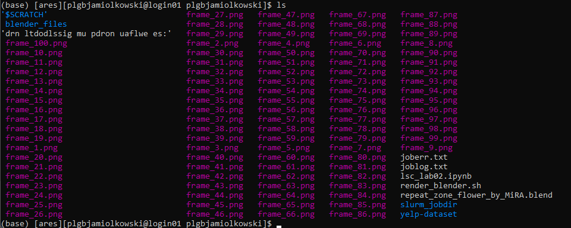

Creating new folder called 'blender_frames', moving all frames to this new location and verifying if the images were rendered successfully.

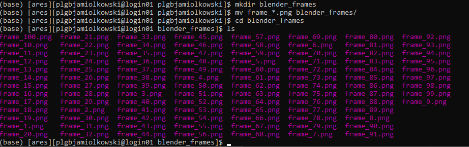

Copying the entire directory folder from the access server ares.cyfronet.pl with compression enabled to the local machine's current directory.

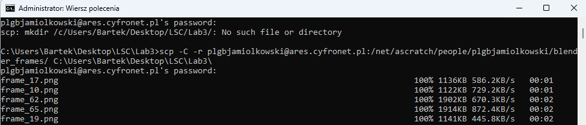

Verifying if the images look OK.

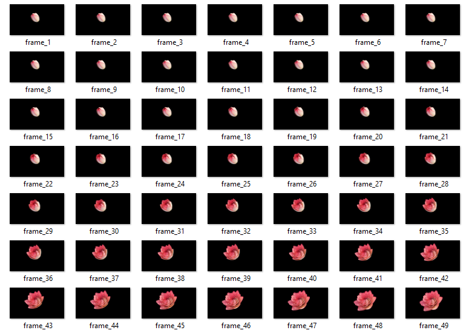

Combining the frames into a video file using a tool FFmpeg (it needs to be installed first).

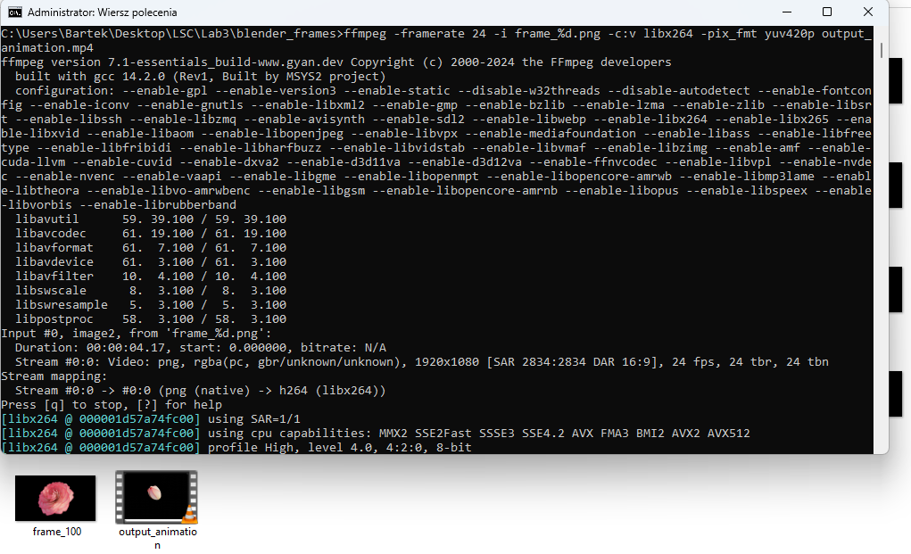

Verifying if the animation looks OK.

```python
from IPython.display import Video

video_path = 'blender_frames/output_animation.mp4'
video = Video(video_path, embed=True, width=800, height=600)  # Adjust the size as needed
video
```

[video not shown]

### Assignment 2

Providing a part of hpc-jobs-history command output with information about my jobs.

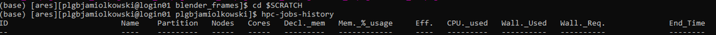

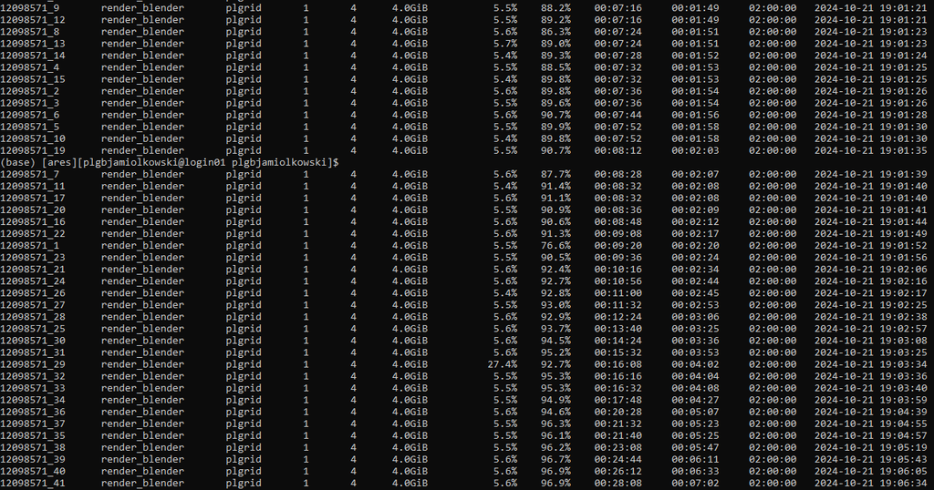

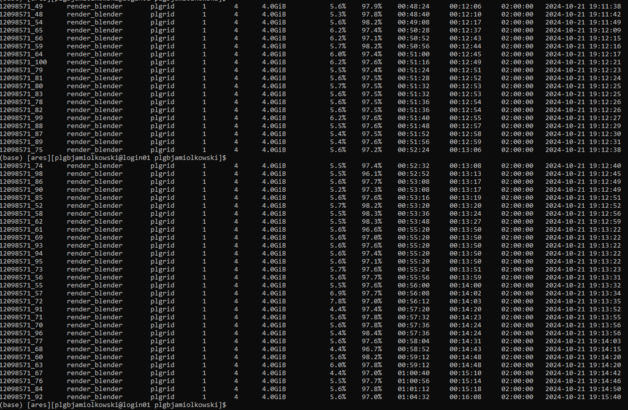

Displaying a list of all available fields that can be used with the sacct command to format output (CSV file containing information about all jobs done in this Assignment 1)

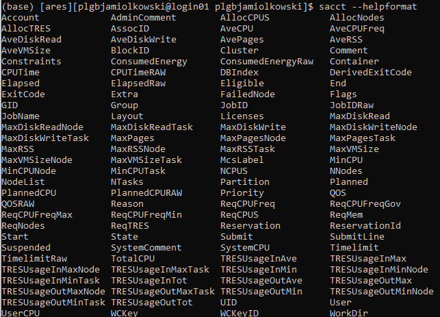

Extracting batch job information to SCV file.

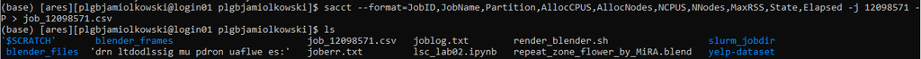

Copying the CSV file from the access server ares.cyfronet.pl to the local machine's current directory.

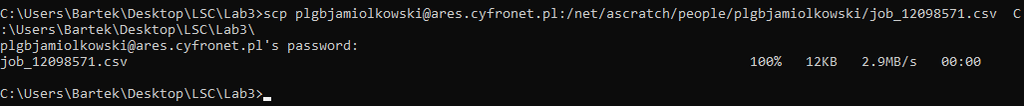

Reading CSV file with information about jobs and calculating efficiency.

```python
import pandas as pd

jobs_df = pd.read_csv('job_12098571.csv', delimiter='|')
jobs_df.head()
```

|  | JobID | JobName | Partition | AllocCPUS | AllocNodes | NCPUS | NNodes | MaxRSS | State | Elapsed |
| --- | --- | --- | --- | --- | --- | --- | --- | --- | --- | --- |
| 0 | 12098571_1 | render_blender | plgrid | 4 | 1 | 4 | 1 | NaN | COMPLETED | 00:02:20 |
| 1 | 12098571_1.batch | batch | NaN | 4 | 1 | 4 | 1 | 230856K | COMPLETED | 00:02:20 |
| 2 | 12098571_2 | render_blender | plgrid | 4 | 1 | 4 | 1 | NaN | COMPLETED | 00:01:54 |
| 3 | 12098571_2.batch | batch | NaN | 4 | 1 | 4 | 1 | 235768K | COMPLETED | 00:01:54 |
| 4 | 12098571_3 | render_blender | plgrid | 4 | 1 | 4 | 1 | NaN | COMPLETED | 00:01:54 |

```python
def elapse_to_hours(elapsed):
    hours, minutes, seconds = map(int, elapsed.split(':'))
    return hours + minutes / 60 + seconds / 3600

jobs_df['Elapsed_Hours'] = jobs_df['Elapsed'].apply(elapse_to_hours)
jobs_df['CPU_Used'] = jobs_df['AllocCPUS'] * jobs_df['Elapsed_Hours']

jobs_df.head()
```

|  | JobID | JobName | Partition | AllocCPUS | AllocNodes | NCPUS | NNodes | MaxRSS | State | Elapsed | Elapsed_Hours | CPU_Used |
| --- | --- | --- | --- | --- | --- | --- | --- | --- | --- | --- | --- | --- |
| 0 | 12098571_1 | render_blender | plgrid | 4 | 1 | 4 | 1 | NaN | COMPLETED | 00:02:20 | 0.038889 | 0.155556 |
| 1 | 12098571_1.batch | batch | NaN | 4 | 1 | 4 | 1 | 230856K | COMPLETED | 00:02:20 | 0.038889 | 0.155556 |
| 2 | 12098571_2 | render_blender | plgrid | 4 | 1 | 4 | 1 | NaN | COMPLETED | 00:01:54 | 0.031667 | 0.126667 |
| 3 | 12098571_2.batch | batch | NaN | 4 | 1 | 4 | 1 | 235768K | COMPLETED | 00:01:54 | 0.031667 | 0.126667 |
| 4 | 12098571_3 | render_blender | plgrid | 4 | 1 | 4 | 1 | NaN | COMPLETED | 00:01:54 | 0.031667 | 0.126667 |

```python
total_cpu_used = jobs_df['CPU_Used'].sum()
total_wall_time_used = jobs_df['Elapsed_Hours'].sum()
efficiency = total_cpu_used / total_wall_time_used
```

```python
print(f'Efficiency: {efficiency}')
```

```
Efficiency: 4.0
```

### Assignment 3

Estimating how many CPU-hours were used for the whole animation.

```python
print(f'CPU-hours: {round(float(total_cpu_used), 2)}')
```

```
CPU-hours: 119.49
```

### Assignment 4

Answering the question: How many CPUs/threads blender uses?

```python
unique_cpus = jobs_df['AllocCPUS'].unique()
unique_cpus
```

```
array([4])
```

In this solution blender typicaly uses 4 CPUs/threads.